# Wine Quality

This report shows how different red wine’s properties affect its quality. To do it, a dataset with the information of 1599 wines is analyzed. It registers properties such as its Ph, acidity, alcohol, density, residual sugar, among others. Each wine is ranked in a scale from 1 to 10 where 1 is very bad and 10 excellent.

I start with a univariable analysis by plotting the different variables available. Then we continue with a multivariable analysis to find correlations between them and finally, with a better understanding of the variables’ behavior, a lineal model is created to predict the wine quality based on its properties.

# Univariate Plots Section

In this section I do a preliminary exploration of the information available, starting by a summary of the dataset, showing its structure and the wine properties with some statistics values. Then a plot for each variable is created to understand the structure of each of them.

## Summary of the Dataset

```
## 'data.frame':    1599 obs. of  15 variables:
##  $ X                   : int  1 2 3 4 5 6 7 8 9 10 ...
##  $ fixed.acidity       : num  7.4 7.8 7.8 11.2 7.4 7.4 7.9 7.3 7.8 7.5 ...
##  $ volatile.acidity    : num  0.7 0.88 0.76 0.28 0.7 0.66 0.6 0.65 0.58 0.5 ...
##  $ citric.acid         : num  0 0 0.04 0.56 0 0 0.06 0 0.02 0.36 ...
##  $ residual.sugar      : num  1.9 2.6 2.3 1.9 1.9 1.8 1.6 1.2 2 6.1 ...
##  $ chlorides           : num  0.076 0.098 0.092 0.075 0.076 0.075 0.069 0.065 0.073 0.071 ...
##  $ free.sulfur.dioxide : num  11 25 15 17 11 13 15 15 9 17 ...
##  $ total.sulfur.dioxide: num  34 67 54 60 34 40 59 21 18 102 ...
##  $ density             : num  0.998 0.997 0.997 0.998 0.998 ...
##  $ pH                  : num  3.51 3.2 3.26 3.16 3.51 3.51 3.3 3.39 3.36 3.35 ...
##  $ sulphates           : num  0.56 0.68 0.65 0.58 0.56 0.56 0.46 0.47 0.57 0.8 ...
##  $ alcohol             : num  9.4 9.8 9.8 9.8 9.4 9.4 9.4 10 9.5 10.5 ...
##  $ quality             : Ord.factor w/ 6 levels "3"<"4"<"5"<"6"<..: 3 3 3 4 3 3 3 5 5 3 ...
##  $ rating              : Ord.factor w/ 5 levels "very bad"<"bad"<..: 3 3 3 3 3 3 3 4 4 3 ...
##  $ alcohol.level       : Ord.factor w/ 4 levels "low"<"moderate"<..: 1 1 1 1 1 1 1 1 1 1 ...
```

```
##        X          fixed.acidity   volatile.acidity  citric.acid
##  Min.   :   1.0   Min.   : 4.60   Min.   :0.1200   Min.   :0.000
##  1st Qu.: 400.5   1st Qu.: 7.10   1st Qu.:0.3900   1st Qu.:0.090
##  Median : 800.0   Median : 7.90   Median :0.5200   Median :0.260
##  Mean   : 800.0   Mean   : 8.32   Mean   :0.5278   Mean   :0.271
##  3rd Qu.:1199.5   3rd Qu.: 9.20   3rd Qu.:0.6400   3rd Qu.:0.420
##  Max.   :1599.0   Max.   :15.90   Max.   :1.5800   Max.   :1.000
##  residual.sugar     chlorides       free.sulfur.dioxide
##  Min.   : 0.900   Min.   :0.01200   Min.   : 1.00
##  1st Qu.: 1.900   1st Qu.:0.07000   1st Qu.: 7.00
##  Median : 2.200   Median :0.07900   Median :14.00
##  Mean   : 2.539   Mean   :0.08747   Mean   :15.87
##  3rd Qu.: 2.600   3rd Qu.:0.09000   3rd Qu.:21.00
##  Max.   :15.500   Max.   :0.61100   Max.   :72.00
##  total.sulfur.dioxide    density             pH          sulphates
##  Min.   :  6.00       Min.   :0.9901   Min.   :2.740   Min.   :0.3300
##  1st Qu.: 22.00       1st Qu.:0.9956   1st Qu.:3.210   1st Qu.:0.5500
##  Median : 38.00       Median :0.9968   Median :3.310   Median :0.6200
##  Mean   : 46.47       Mean   :0.9967   Mean   :3.311   Mean   :0.6581
##  3rd Qu.: 62.00       3rd Qu.:0.9978   3rd Qu.:3.400   3rd Qu.:0.7300
##  Max.   :289.00       Max.   :1.0037   Max.   :4.010   Max.   :2.0000
##     alcohol      quality       rating       alcohol.level
##  Min.   : 8.40   3: 10   very bad :   0   low      :1508
##  1st Qu.: 9.50   4: 53   bad      :  63   moderate :  77
##  Median :10.20   5:681   average  :1319   high     :  13
##  Mean   :10.42   6:638   good     : 217   very high:   1
##  3rd Qu.:11.10   7:199   very good:   0
##  Max.   :14.90   8: 18
```

## Plots

### Quality

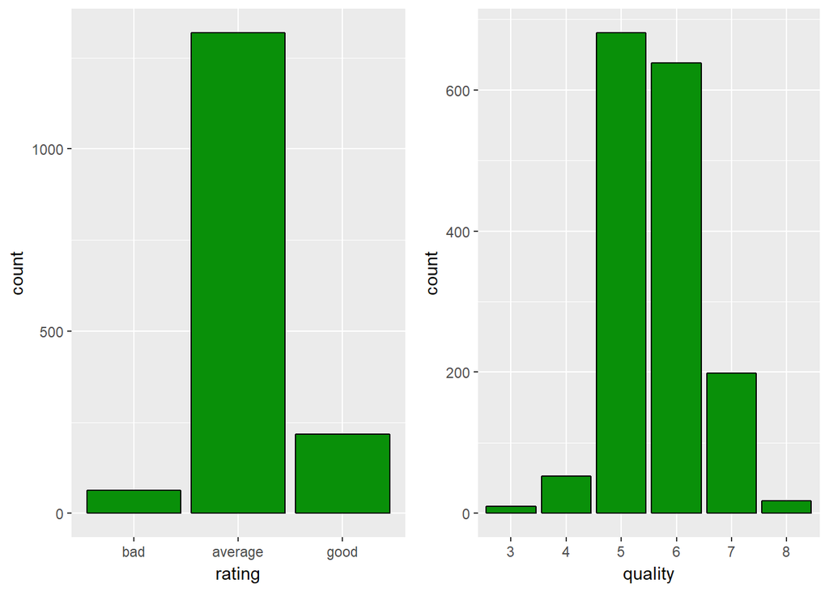

We can see that most values are between 5 and 6, which means that most wines in the sample have an average quality. To get a better sense of this I created a new variable called “ranking” based in the quality variable, as follows:

- Very bad: 1-2
- Bad: 3-4
- Average: 5-6
- Good: 7-8
- Excellent: 9-10

In this dataset there are no records of very bad or excellent wines. 1319 wines in the dataset are of average quality according to this ranking, corresponding to 82.5% of the total dataset.

### Acidity

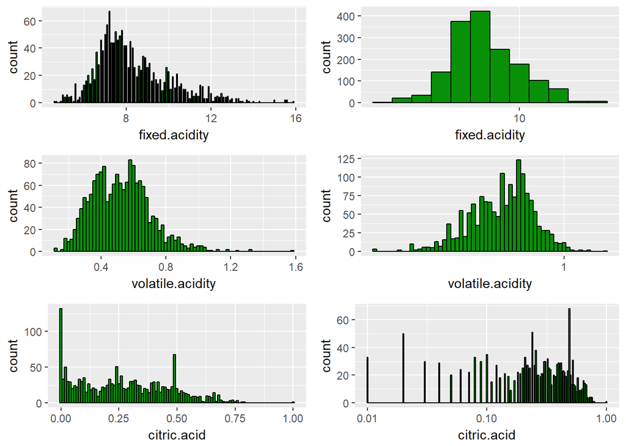

Fixed acidity has a right skewed distribution, with an average of 8.32. Volatile acidity has a bimodal distribution, with peaks and with an average of 0.527. Citric acid hasn’t a clear distribution, it has two peak values, the first in 0 and the other in 0.48 approx., with a mean of 0.27. The first peak may be due to missing values. Using a log scale for these variables, as seen on the right side, fixed acidity remains a right skewed distribution but gets closer to a normal one. Volatile acidity turns into a left skewed distribution. Citric acid remains without a clear distribution.

### pH

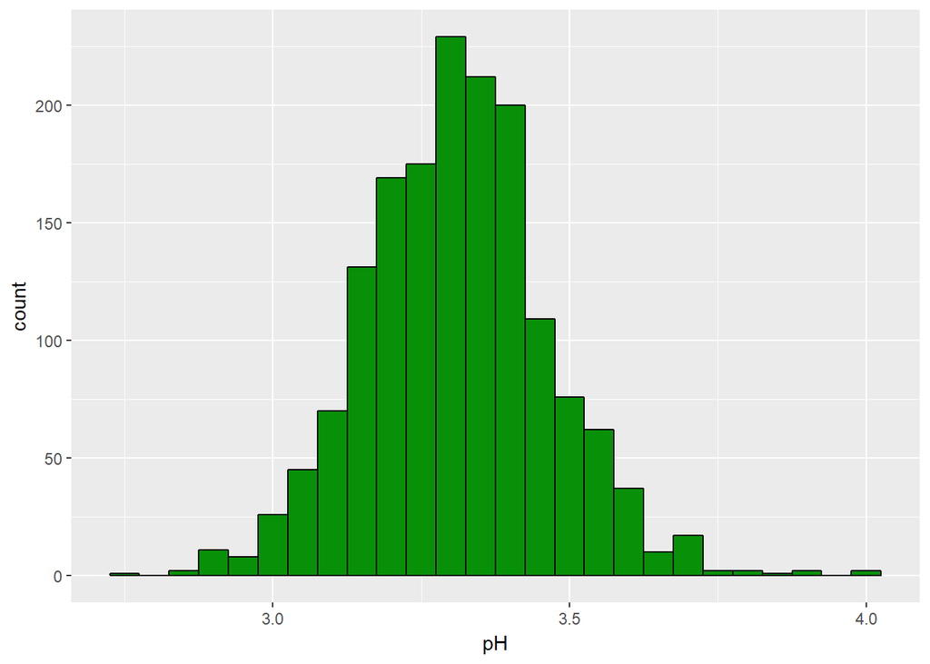

Ph has a normal distribution. Most values are between 3 and 3.5.

### Residual sugar

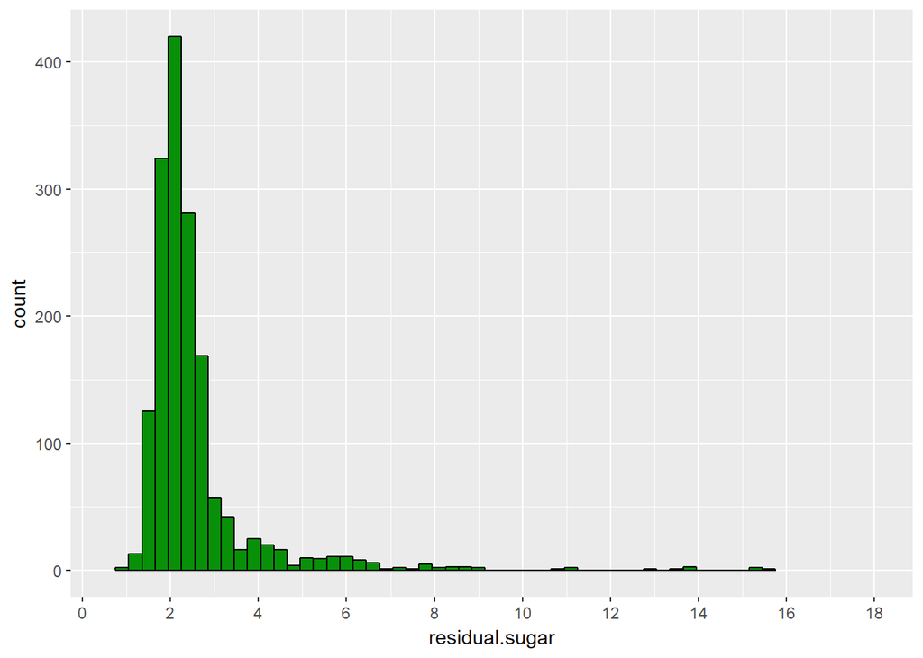

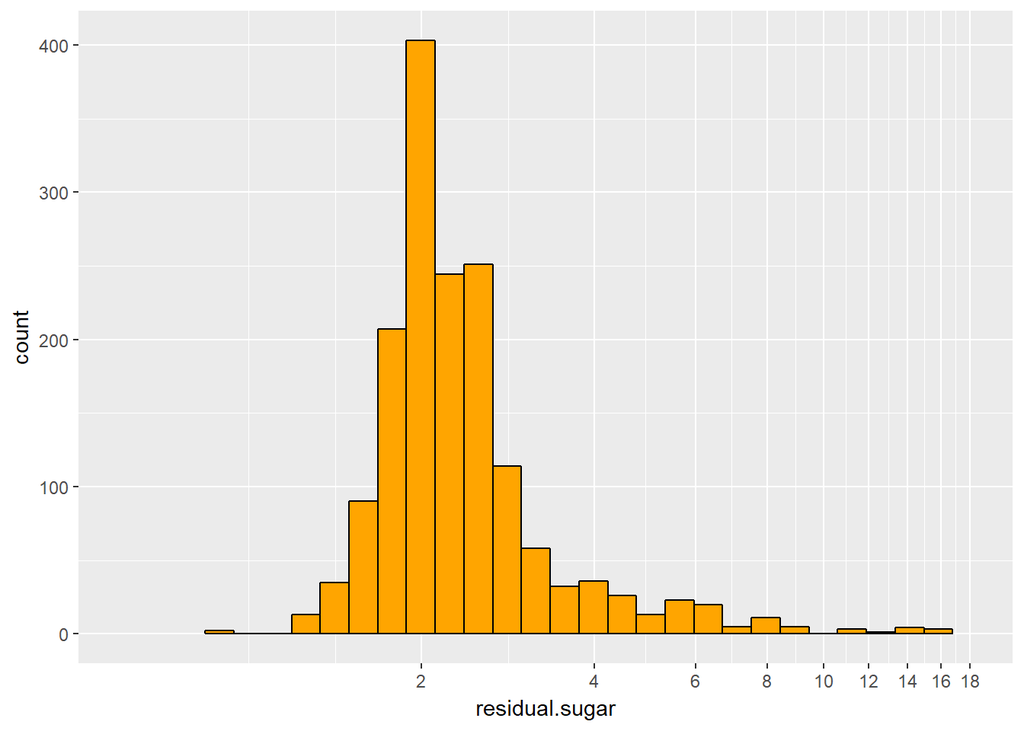

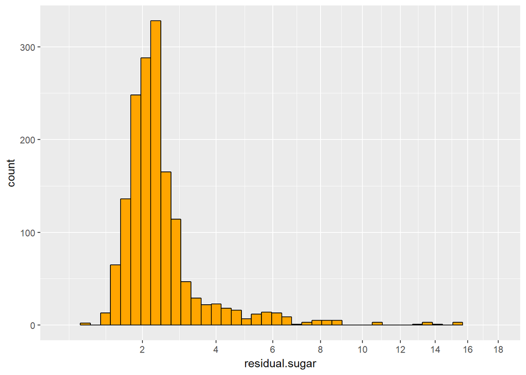

Residual sugar seems to have a right skewed distribution, although many of the values on the right-hand side could be outliers. After applying log10 and square root scales (graphs above) the distribution maintains a right skewed form.

### Alcohol

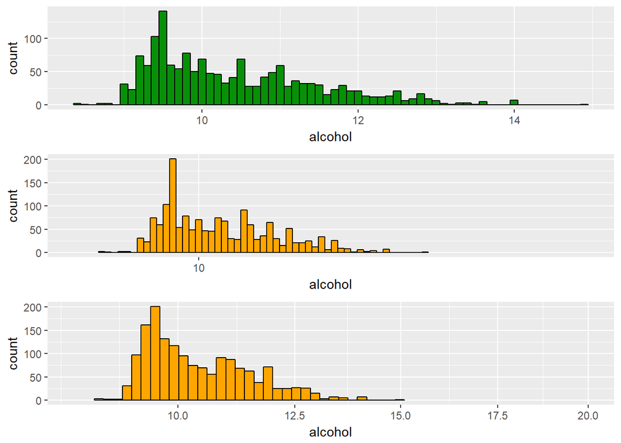

Alcohol also has a right skewed distribution, which persists after applying the same transformations made for residual sugar.

### Density

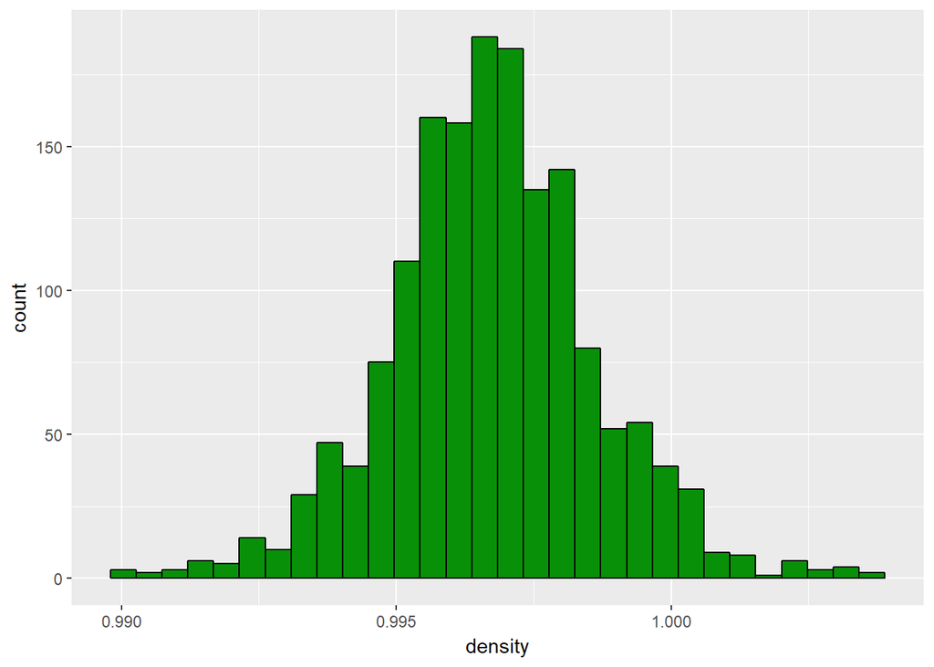

Density has a clear normal distribution.

### Chlorides

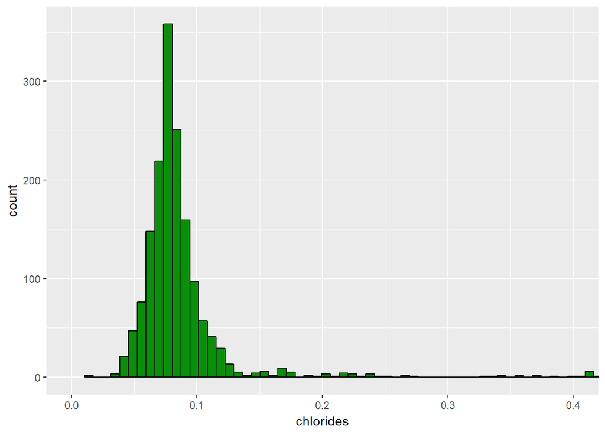

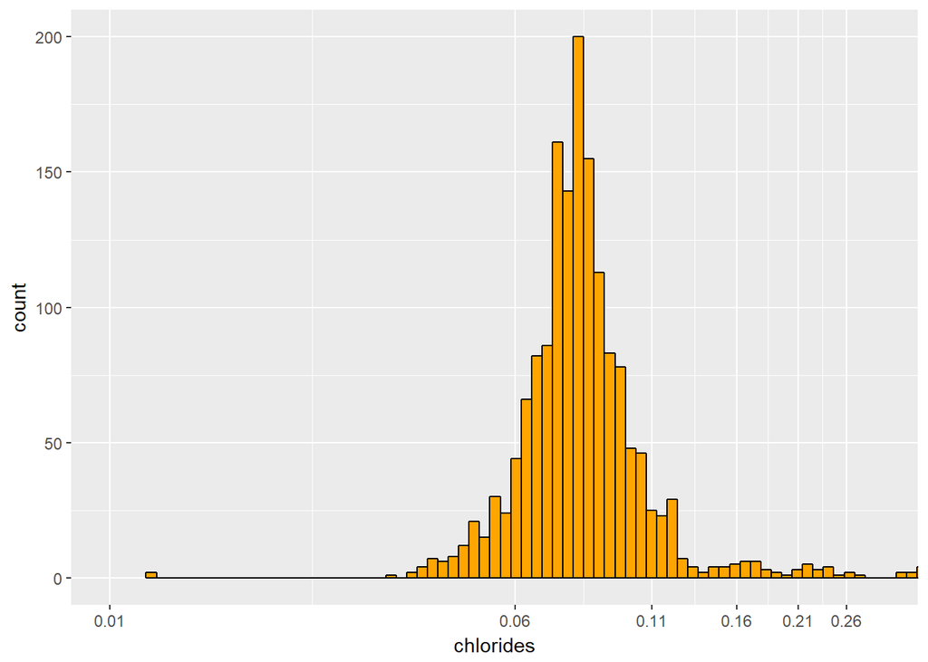

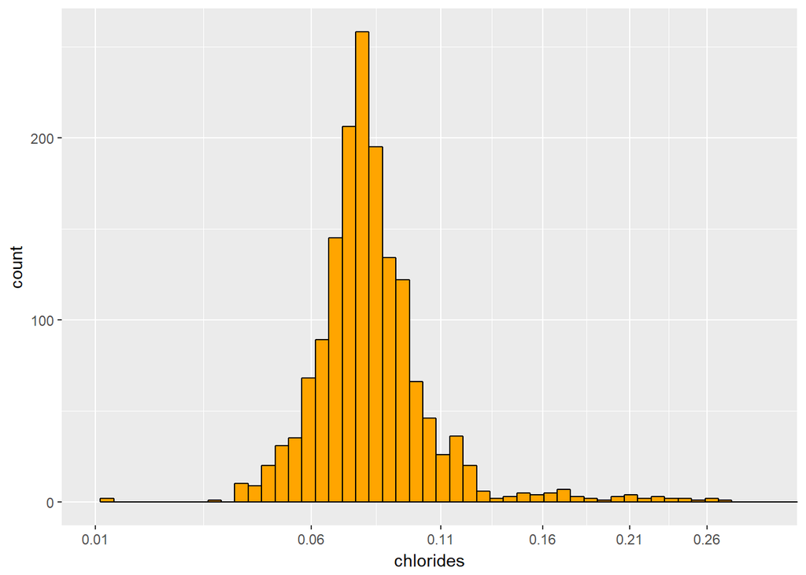

Chlorides seem to have a normal distribution for values below 0.2 (more than 95% of the sample) with a long tail on the right. Using a log scale and square root transformation, the distribution gets closer to a normal with a shorter tail.

### Free sulfur dioxide

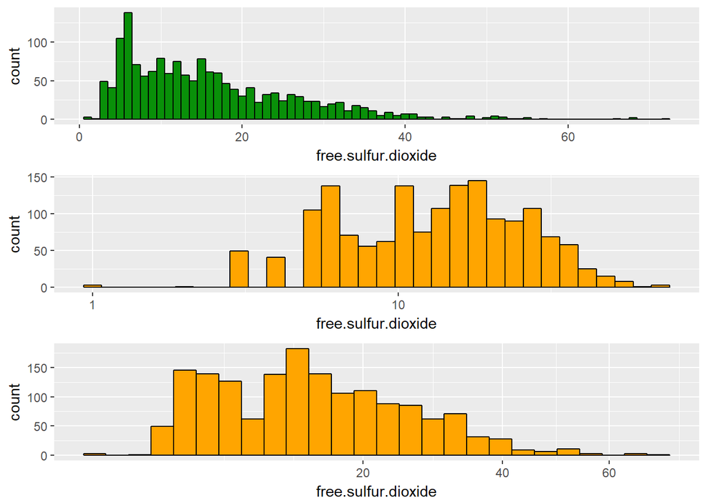

Free sulfur has a clear right skewed distribution with its peak around 6. Applying the transformations done for previous variables, the distribution becomes left - skewed for the log scale and right skewed for the square root scale.

### Total sulfur dioxide

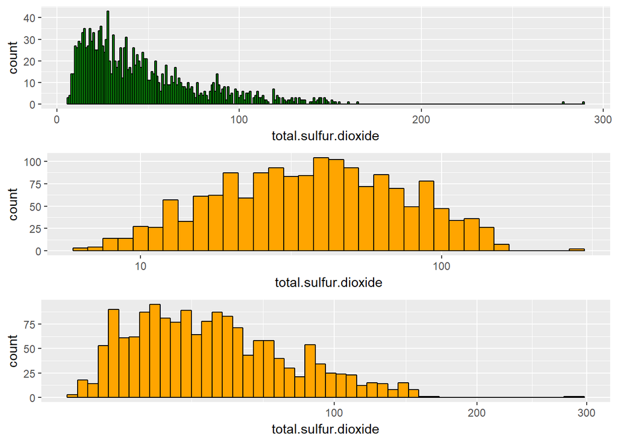

Similarly, total sulfur dioxide has a clear right skewed distribution. Applying the transformations done for previous variables, the distribution gets closer to a normal for the log scale and remains right skewed for the square root scale.

### Sulphates

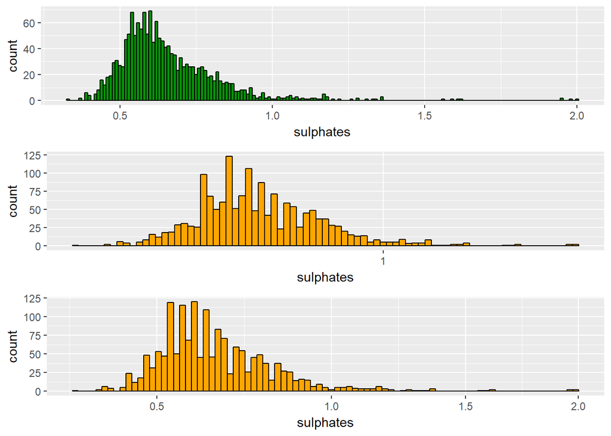

In the same fashion, the sulfates variable has a clear right skewed distribution. Applying the transformations done for previous variables, the distribution gets closer to a normal for the log scale and remains right skewed for the square root scale.

# Univariate Analysis

### What is the structure of your dataset?

- Most of the wines have a quality score between 5 and 6.
- The mean percentage of alcohol is 10, having a range between 8.40 and 14.9.
- There are only acid wines, the highest ph is 4.
- About 75% of the wines have a residual sugar less than 2.6 with a mean of 2.54 and a maximum value of 15.5 which represent an outlier.

### What is/are the main feature(s) of interest in your dataset?

The main feature of the dataset is the quality of the wine. The objective of this report is to find the features that determine it.

### What other features in the dataset do you think will help support your investigation into your feature(s) of interest?

Features as the acidity, alcohol and residual sugar might affect the quality of the wine. I think acidity could impact most in the wine’ quality so it will be important to analyze volatile acidity, citric acid, fixed acidity, as well as Ph.

### Did you create any new variables from existing variables in the dataset?

I created two new ordered factor variables:

1. Alcohol level: this variable shows the level of alcohol for each sample. After a research I found that the level is distributed as follow:
- Low: < 12.5
- Moderate: 12.5-13.5
- High: 13.5 - 14.5
- Very high: > 14.5 Most of the wines are concentrated in the low level, 77 are in moderate, 13 in high and only 1 in very high.
2. Rating: this variable is created to label the wines’ quality, having the following distribution:
- Very bad: 1-2
- Bad: 3-4
- Average: 5-6
- Good: 7-8
- Excellent: 9-10

### Of the features you investigated, were there any unusual distributions? Did you perform any operations on the data to tidy, adjust, or change the form of the data? If so, why did you do this?

I applied log and square root transformations to some variables to better understand its distributions.

- Citric acid hasn’t a clear distribution. It seems to have many missing values.
- Residual sugar, chlorides seem to have outliers.
- Alcohol is right skewed. I applied log scale, but it remains right skewed.

# Bivariate Plots Section

I start by doing a correlation matrix between the variables to get an idea of which ones are more relevant to understand quality´s variation.

To do it, I excluded the X variable because it only enumerates the different wines’ instances. Also I removed the factor variables (alcohol.level and rating) because they were created with features that were already in the dataset

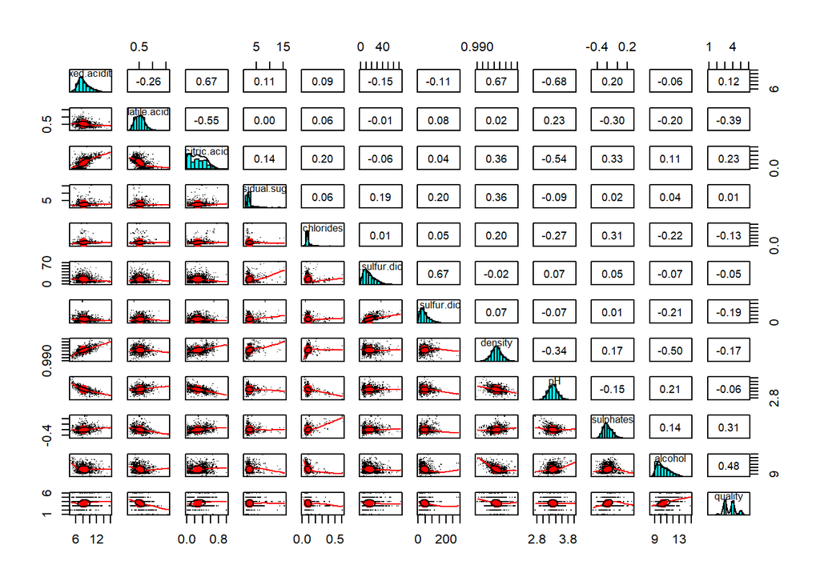

Variables with higher correlation with Quality:

- Alcohol (0.48)
- Volatile acidity (-0.39)
- Sulphates (0.31)
- Citric acidity (0.23)

Other important correlations:

- Ph and fixed acidity (-0.68)
- Fixed and citric acidity (0.67)
- Density and fixed acidity (0.67)
- Free and total sulfur dioxide (0.67)
- Volatile and citric acidity (-0.55)
- Ph and citric acidity (-0.54)
- Alcohol and density (-0.5)

### Quality vs Alcohol

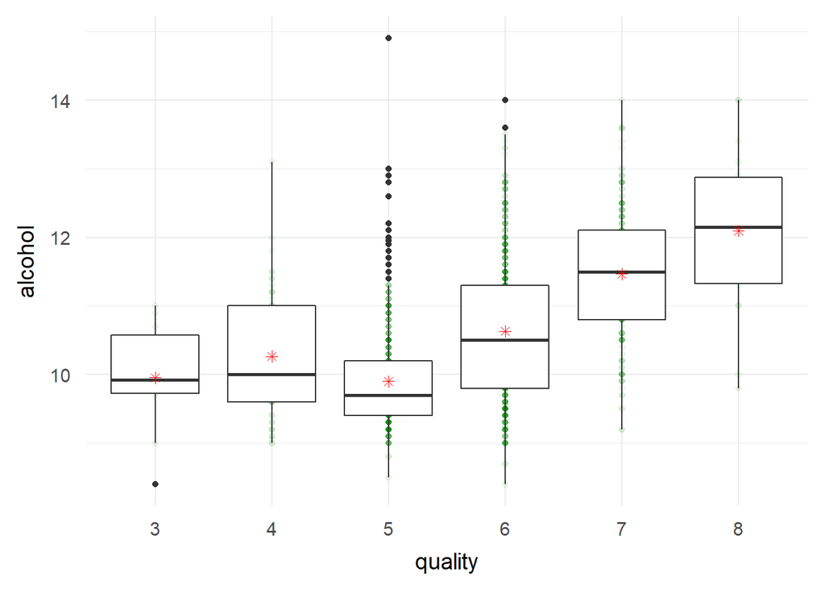

### Quality vs Sulphates(log10)

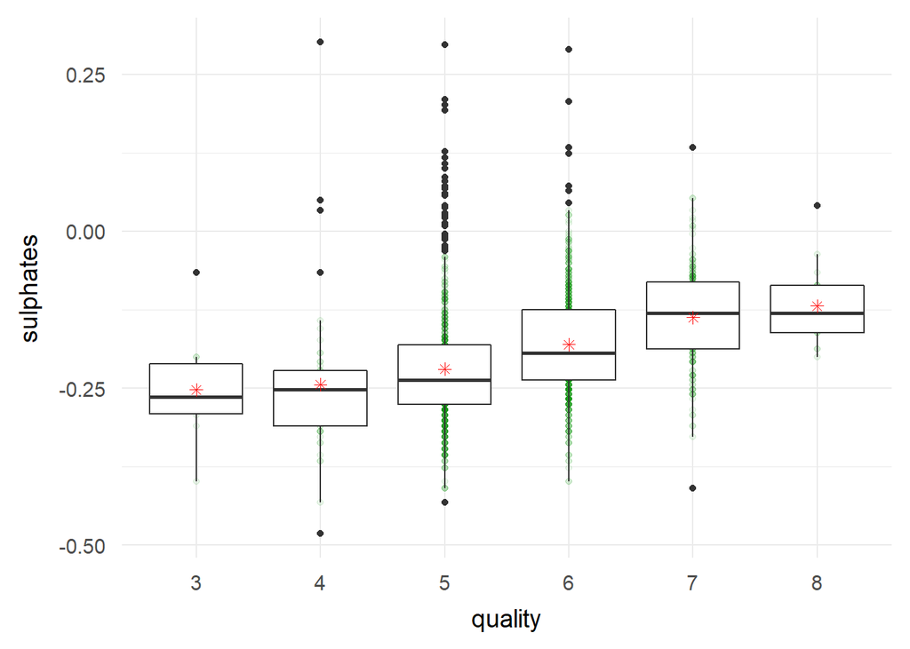

Sulphates (log10) and quality show a similar, although less strong, correlation than the one studied before. A positive relation starts to become clear for qualities beyond 5. The graph shows many outliers.

### Quality vs Volatile Acidity

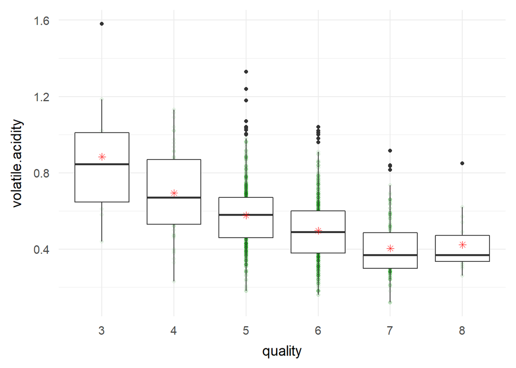

Volatile acidity has a clear negative correlation with wine quality. The graph also shows many outliers.

### Quality vs Citric Acidity

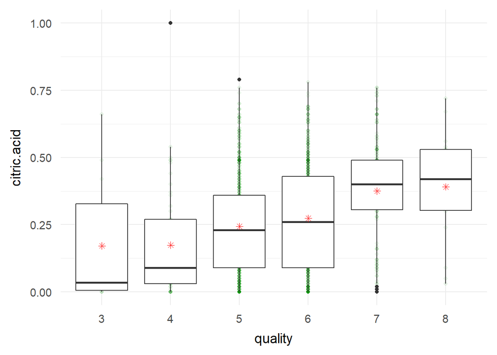

Citric acidity seems to have a positive correlation with wine quality. However, this graph shows bigger sizes of the boxes, indicating a higher dispersion of the data across the different quality levels.

### Alcohol vs Density

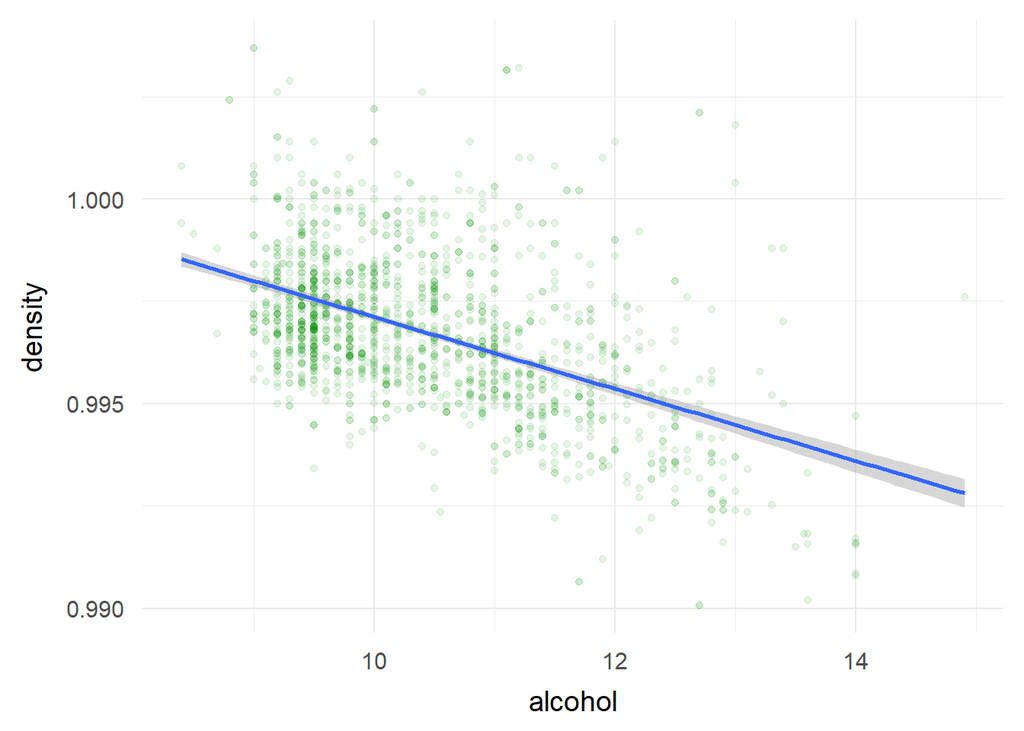

With density and alcohol, we start graphing continuous variables. We can see a negative correlation between these two variables. The introduction of alcohol to a wine appears to reduce its density

### Fixed Acidity vs Citric Acidity

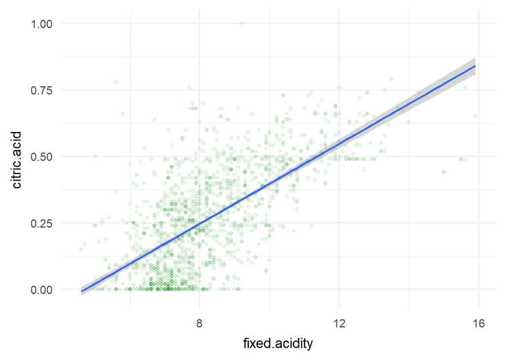

Citric and fixed acidity show a positive correlation.

### Fixed Acidity vs pH

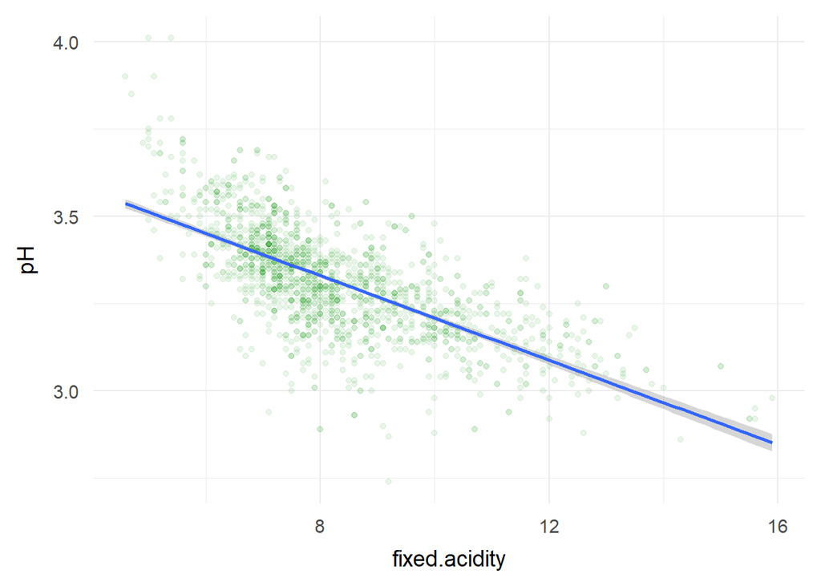

pH and fixed acidity show a strong negative correlation.

### Volatile Acidity vs Sulphates(log10)

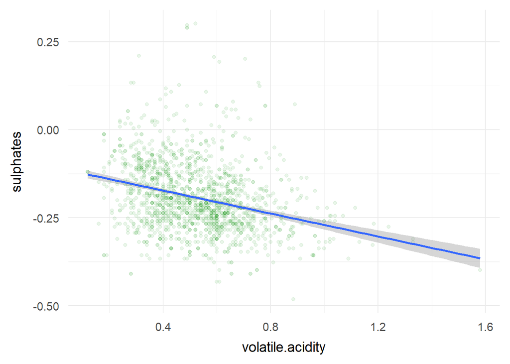

# Bivariate Analysis

### Talk about some of the relationships you observed in this part of the investigation. How did the feature(s) of interest vary with other features in the dataset?

In this exploration we have seen that although there are clear relations there are not strong enough to conclude that a single variable determines the behavior of our feature of interest, in this case wine quality. From the analysis we can observe that the strongest correlation of wines´ quality is with alcohol. More specifically, lower qualities wines tend to have lower alcohol levels, and inversely good ones have higher. For the vast majority of average wines this relation is less clear.

### Did you observe any interesting relationships between the other features (not the main feature(s) of interest)?

In our analysis we could see that some variables have strong relationship, which may be due to chemical properties between some of the features present in wine.For example, fixed acidity is strongly correlated with both pH and citric acidity. Density and alcohol also have a clear negative correlation.

### What was the strongest relationship you found?

The strongest correlation was between pH and fixed acidity.

# Multivariate Plots Section

### Quality by Fixed Acidity and pH

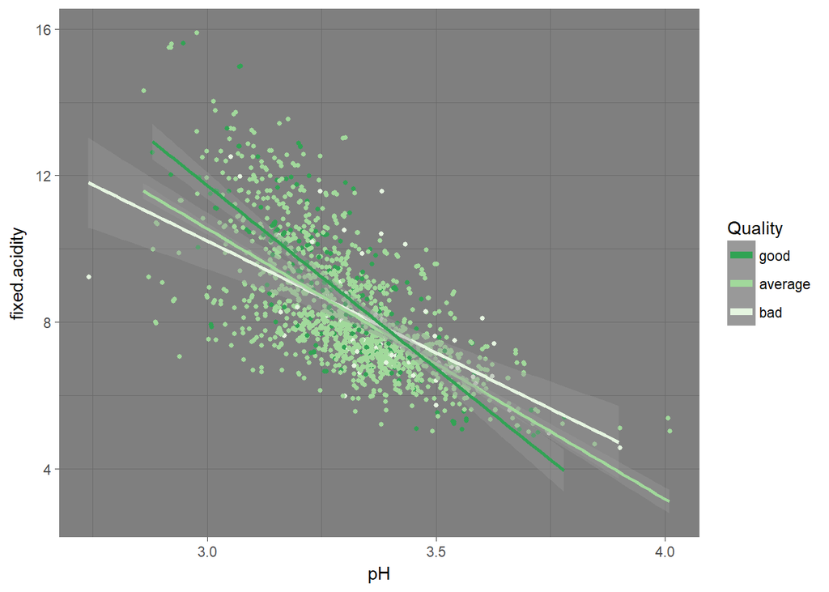

This first multivariate plot shows the strong negative correlation between fixed acidity and pH (that we have already identified). This relation doesn´t seem to affect wine´s quality (as we saw on the table, correlation of these two variables with quality is just 0.12 and -0.06 respectively).

### Quality by Alcohol

For the next round of plots, we study the relation between wine´s quality, alcohol levels and several other features of interest.

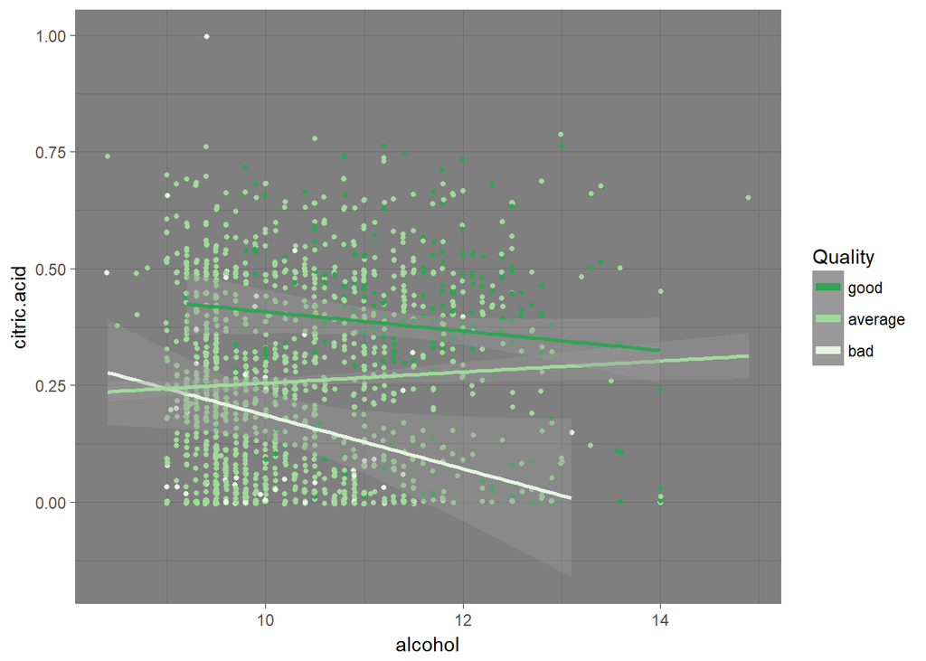

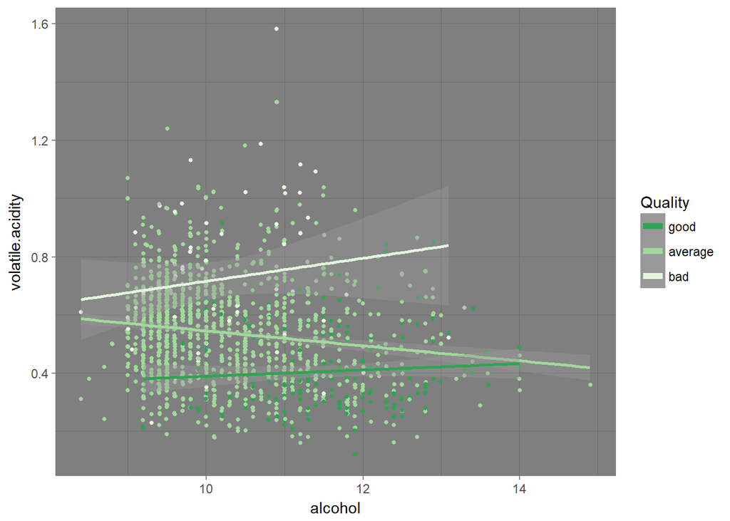

In this graph, comparing volatile acidity, alcohol and quality, we can see, as we have discussed before, that good quality wines have higher alcohol levels and lower volatile acidity. Bad wines have lower alcohol levels and higher volatile acidity. We also observe that there´s not a strong correlation between volatile acidity and alcohol.

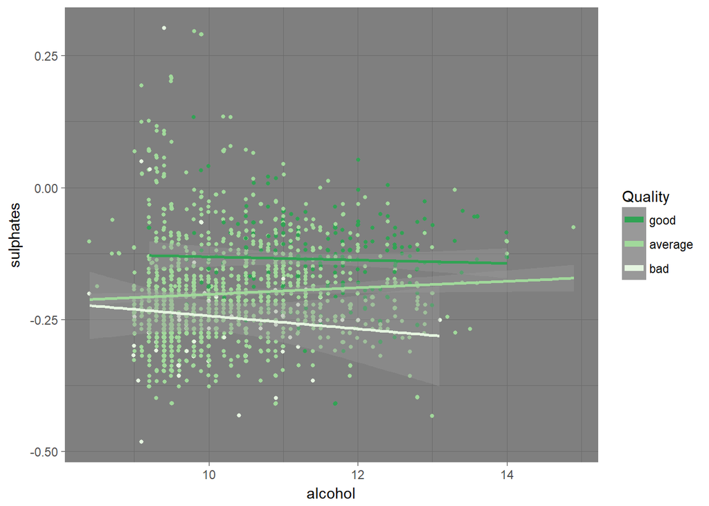

### Quality by Alcohol, Volatile Aidity and Sulphates (log10)

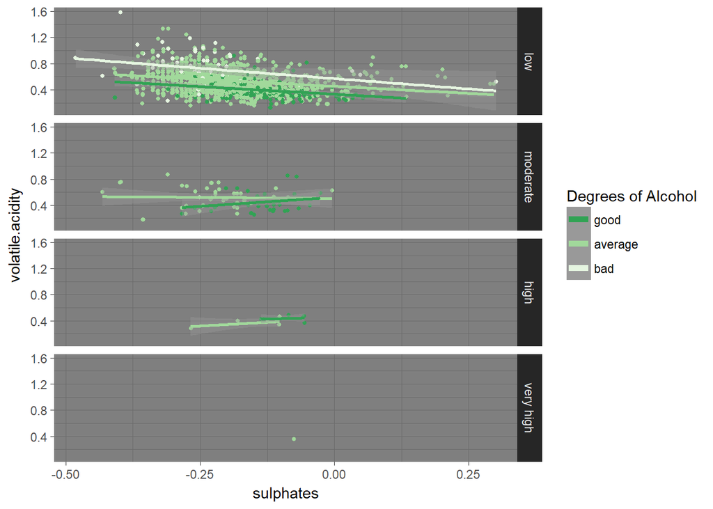

This last graph puts together quality with three variables that we have studied in the two last plots, and which are the ones with the higher correlation with our variable of interest. We have four subplots according to the different wines´ alcohol levels. The first thing that is clear is that bad wines all have low alcohol levels. We can also observe that across different levels of alcohol, quality is lower for higher levels of volatile acidity.

Althought I didn’t see a very strong correation in the plots, I built a linear model using the variables with the higest correlation with the wines’ quality to predict it.

```
##
## Calls:
## m1: lm(formula = as.numeric(quality) ~ alcohol, data = rw)
## m2: lm(formula = as.numeric(quality) ~ alcohol + sulphates, data = rw)
## m3: lm(formula = as.numeric(quality) ~ alcohol + sulphates + volatile.acidity,
##     data = rw)
## m4: lm(formula = as.numeric(quality) ~ alcohol + sulphates + volatile.acidity +
##     citric.acid, data = rw)
##
## ============================================================================
##                          m1            m2            m3            m4
## ----------------------------------------------------------------------------
##   (Intercept)          -0.125         0.541**       1.369***      1.444***
##                        (0.175)       (0.177)       (0.184)       (0.196)
##   alcohol               0.361***      0.335***      0.303***      0.303***
##                        (0.017)       (0.016)       (0.016)       (0.016)
##   sulphates                           2.070***      1.477***      1.518***
##                                      (0.177)       (0.177)       (0.181)
##   volatile.acidity                                 -1.156***     -1.217***
##                                                    (0.097)       (0.112)
##   citric.acid                                                    -0.113
##                                                                  (0.103)
## ----------------------------------------------------------------------------
##   R-squared             0.227         0.288         0.345         0.346
##   adj. R-squared        0.226         0.287         0.344         0.344
##   sigma                 0.710         0.682         0.654         0.654
##   F                   468.267       322.031       280.646       210.808
##   p                     0.000         0.000         0.000         0.000
##   Log-likelihood    -1721.057     -1655.601     -1587.752     -1587.153
##   Deviance            805.870       742.522       682.108       681.597
##   AIC                3448.114      3319.202      3185.503      3186.306
##   BIC                3464.245      3340.711      3212.389      3218.569
##   N                  1599          1599          1599          1599
## ============================================================================
```

# Multivariate Analysis

### Talk about some of the relationships you observed in this part of the investigation. Were there features that strengthened each other in terms of looking at your feature(s) of interest?

In this section we corroborated the strong correlation of wine´s quality with three other variables (alcohol, sulphates and volatile acidity). We also confirmed that these correlations occur despite the fact the between them these three variables don´t have evident relations. We observed that alcohol has a low correlation with either sulphates and volatile acidity.

### Were there any interesting or surprising interactions between features?

What was most interesting to me from this exploration was the fact that alcohol had such a powerful effect on quality! However, clearly alcohol doesn´t explain by itself quality. Other properties seem to be secondary. The other thing that was interesting was understanding the relations between the different components (for example pH and fixed acidity). Even if I´m not very literate in the chemistry behind wine, we can observe how these different components relate to each other (or not! For example, chlorides levels don´t seem to have any clear relation with other components or wine´s quality).

### OPTIONAL: Did you create any models with your dataset? Discuss the strengths and limitations of your model.

# Final Plots and Summary

### Plot One

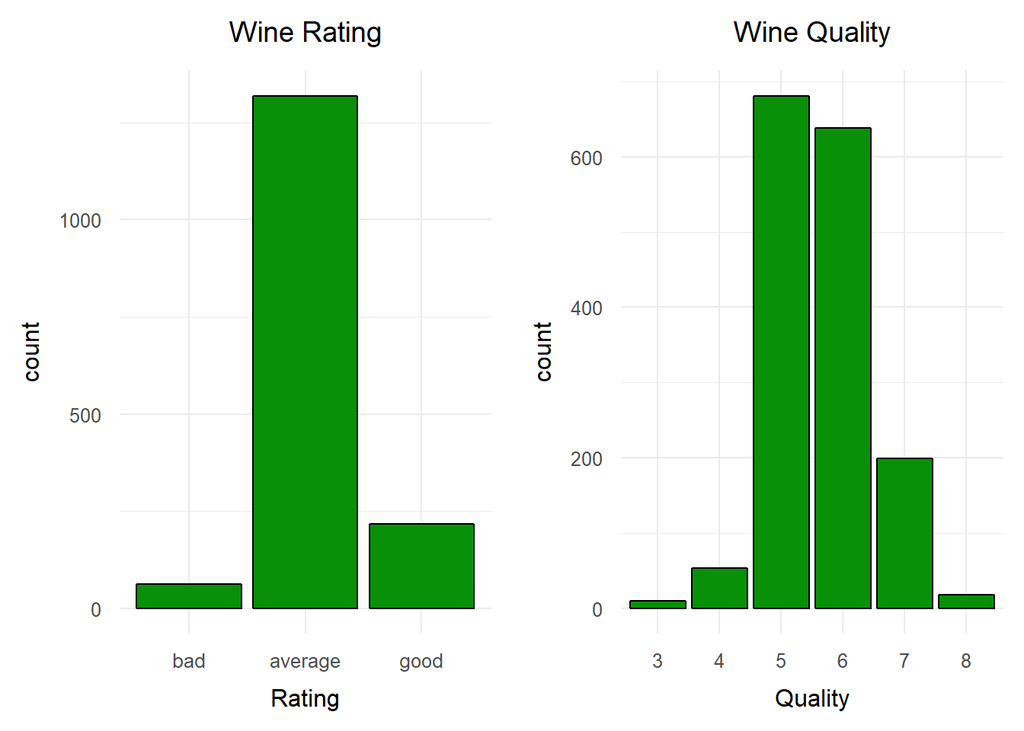

### Description One

This first histogram showed us the distribution of wine´s quality. We can observe a normal distribution, with most wines of average quality. This observation was very useful for the following explorations.

### Plot Two

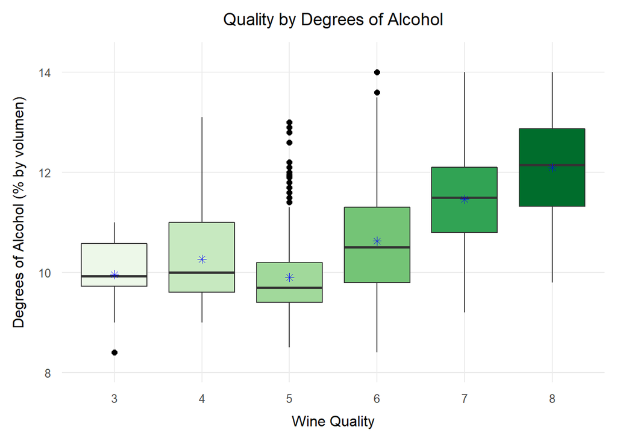

### Description Two

This second graph showed us the positive correlation between alcohol and quality. We also observed many outliers for average wines. We also learned that higher quality wines clearly have higher alcohol levels.

### Plot Three

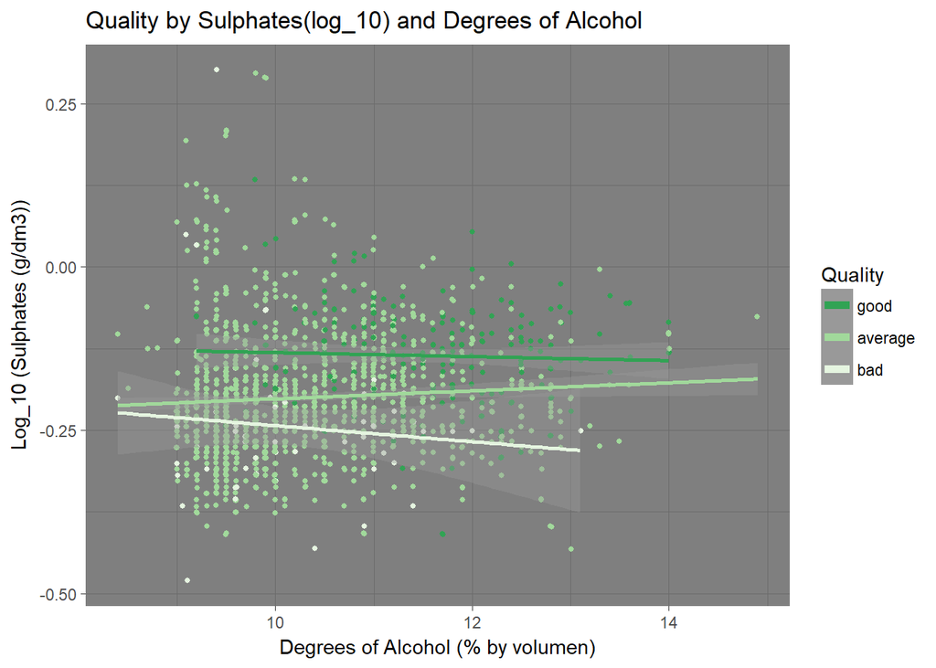

### Description Three

The third graph is important because it shows the combined positive relation between quality and alcohol and sulphates. Bad wines don´t surpass the 13 degrees of alcohol, whereas good wines don´t have less than 9.2 degrees of alcohol. Average wines have very different alcohol and sulphates levels.

# Reflection

In this exercise we incrementally learned more about the features affecting wine´s quality, and the connections between them. From the first part of the analysis we observed that many variables had a right skewed distribution and the presence of many outliers. Then, after doing the correlation table, we distinguished three variables that impacted quality the most: alcohol, sulphates and volatile acidity. This discovery helped us structuring the rest of the study.  
With bivariate and multivariate we understood this correlations and observed how strong they were for different quality levels.  
Because of the structure of the dataset, most wines were of average quality. This became a problem as the variables with higher correlations had a clear relation with lower or higher quality wines, but for average quality none of these relations were very clear. This may explain why the lineal model made at the end doesn´t have much explanatory power.

For further analysis I would like to obtain a database with more data points for bad and good quality. In this exercise we saw that more that 80% of the wines were in the average category, limiting the possibility of having clearer correlations. I also would like to obtain a database of white wines, to discover if the relation we discovered (for example alcohol and quality) also apply.